# Naive Bayes Classifier

Gareth Bayvel

1. Naive Bayes is a probabilistic machine learning algorithm based upon the Bayes Theorem and sees its application in a wide variety of classification tasks.
1. Classification tasks such as:
   - Spam filtering
   - document classifiers
   - sentiment prediction
   - etc

## Why Is It Naive?

Naive Bayes is naive because it assumes **independence** of input features. This means that the input features that go into our model are independent of one another (do not influence one another).

#### Example:

In spam filtering, the two messages below are treated the same due to the independence of each feature:

```
- "Dear Mike, you won".
- "Mike won, Dear you".
```

## Understanding Conditional Probability

Consider a school with 110 students. These 110 students either prefer 'Soccer' or 'Golf' and are seen as either 'Females' or 'Males'.

#### Worked Example

$$\begin{array}{c|c} & \text{Female} & \text{Male} & \text{Total} \\ \hline \text{Soccer} & 31 & 41 & 72\\ \hline \text{Golf} & 9 & 29 & 38\\ \hline \text{Total} & 40 & 70 & 110 \end{array}$$

#### What is the conditional probability that a certain student likes ‘Golf’ given that he is a ‘Man’?

$$P(Golf|Male) = \frac{P(Golf \bigcap Male)}{P(Male)} = \frac{29}{70} = 0.41$$

Additionally, we can consider the conditional probability that a certain student is Male given that they like Golf.

Therefore, the Bayes Rule that we use for Naive Bayes, can be derived from these two notations:

$$P(A|B) = \frac{P(A \bigcap B)}{P(B)}$$$$P(B|A) = \frac{P(A \bigcap B)}{P(A)}$$

# Bayes Theorom

$$P(A|B) = \frac{P(B|A).P(A)}{P(B)}$$$$P(y|X) = \frac{P(X|y).P(y)}{P(X)}$$

```
- P(A|B) is the posterior probability
- P(B|A) is the likelihood of evidence: conditional porbability of X given Y is of a particular class
- P(A) is the prior
- P(B) is the Probability of evidence and it remains static for all classes
```

1. The Bayes Rule allows us to use $P(X|Y)$ from our training dataset to find $P(Y|X)$.

```
- Replacing A and B with X (input features) and Y (target class)
```

1. For our predictions based upon our testing set, our X is known while our target class is unknown. We can compute the probability of Y given X has already happened.

# Worked Example

#### Golfing Dataset

$$\begin{array}{c|c} \text{Outlook} & \text{Windy} & \text{Played Golf} \\ \hline \text{Rainy} & False & N \\ \hline \text{Rainy} & False & Y \\ \hline \text{Sunny} & False & Y \\ \hline \text{Rainy} & True & Y \\ \hline \text{Overcast} & True & Y \\ \hline \text{Overcast} & False & Y \\ \hline \text{Sunny} & True & N \end{array}$$

# Mathematical Walkthrough

$$P(y|X) = \frac{P(X|y).P(y)}{P(X)}$$$$X = (x_1,x_2,x_3,...,x_n)$$

1. Variable y: is the class variable (played golf), which represents if it is suitable to play golf or not given the conditions.
1. Variable X: represents our input features (Outlook and windy)

$$P(y|x_1,...,x_n) = \frac{P(x_1|y).P(x_2|y).P(x_3|y)...P(x_n|y)}{P(x_1).P(x_2).P(x_3)...P(x_n)}$$

We can now substitute the values from our training set into the equation. Notably, the denominator remains static. Therefore, the denominator can be removed and a proportionality can be introduced:

$$P(y|x_1,...,x_n) \propto P(y)\prod_{i=1}^{n} P(x_i|y)$$

#### For multiclass:

$$y = argmax_y P(y)\prod_{i=1}^{n} P(x_i|y)$$

#### Golfing Dataset

$$\begin{array}{c|c} \text{Outlook} & \text{Windy} & \text{Played Golf} \\ \hline \text{Rainy} & False & N \\ \hline \text{Rainy} & False & Y \\ \hline \text{Sunny} & False & Y \\ \hline \text{Rainy} & True & Y \\ \hline \text{Overcast} & True & Y \\ \hline \text{Overcast} & False & Y \\ \hline \text{Sunny} & True & N \end{array}$$

## Played Golf

**Prior**:

P(A) = $\frac{Y}{Y+N}$ = $\frac{5}{7}$

**Likelihood of evidence $P(y|x_1)$**:

P(Played|Rainy) = $\frac{2}{5}$

P(Played|Sunny) = $\frac{1}{5}$

P(Played|Overcast) = $\frac{2}{5}$

**Likelihood of evidence $P(y|x_2)$**:

P(Played|Windy) = $\frac{2}{5}$

P(Played|Not_Windy) = $\frac{3}{5}$

## Not Played Golf

**Prior**:

P(A) = $\frac{N}{Y+N}$ =$\frac{2}{7}$

**Likelihood of evidence $P(y|x_1)$**:

P(Not_Play|Sunny) = $\frac{1}{2}$

P(Not_Play|Overcast) = $\frac{0}{2}$

**Likelihood of evidence $P(y|x_2)$**:

P(Not_Play|Windy) = $\frac{1}{2}$

P(Not_Play|Not_Windy) = $\frac{1}{2}$

$$P(y|x_1,...,x_n) \propto P(y)\prod_{i=1}^{n} P(x_i|y)$$$$P(A).P(Played|Sunny).P(Played|NotWindy)$$$$y = \frac{5}{7}.\frac{1}{5}.\frac{3}{5} = 0.0857$$

# Laplace Correction

1. The value of P(Not_Play | Overcast) was zero in the above example.
1. Therefore, when you have a model that includes this feature, the entire probability will become zero. To avoid this, we increase the count of the variable with zero to a small value.

# Gaussian Naive Bayes

- If we assume that the X follows a particular distribution, then you can plug in the probability density function of that distribution to compute the probability of likelihoods.
- If you assume the X’s follow a Normal (aka Gaussian) Distribution, which is fairly common, we substitute the corresponding probability density of a Normal distribution and call it the Gaussian Naive Bayes. You need just the mean and variance of the X to compute this formula.

$$P(x_i|y) = \frac{1}{\sqrt{2\pi\sigma_y^2}} exp(-\frac{(x_i-y)^2}{2\sigma_y^2})$$

# Worked Example

Below is the head of a dataset containg the information about whether people like or dislike the movie Inception. Additionally, our information contains the amount of Popcorn and candy they eat. Can we predict whether a new observation will like Inception based upon the amount of candy and Popcorn they consume?

#### Likes Inception

$$\begin{array}{c|c} \text{Popcorn} & \text{Candy} & \text{Likes Inception} \\ \hline \text{28} & 0.2 & Y \\ \hline \text{21} & 20 & Y \\ \hline \text{15} & 3 & Y \\ \hline \text{12} & 8 & Y \\ \hline \vdots & \vdots & \vdots \end{array}$$

#### Dislikes Inception

$$\begin{array}{c|c} \text{Popcorn} & \text{Candy} & \text{Likes Inception} \\ \hline \text{13} & 90.7 & N \\ \hline \text{15} & 102.3 & N \\ \hline \text{12} & 50.3 & N \\ \hline \text{10} & 87 & N \\ \hline \vdots & \vdots & \vdots \end{array}$$

## Gaussian Naive Bayes

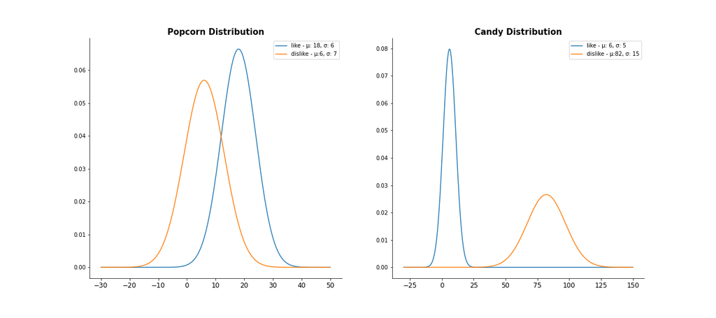

```python
Image('GaussianPopcorn.png')
```

# Gaussian Naive Bayes Prediction

Make a prediction for a person who eats:

```
      - 9 grams of popcorn
      - 63 grams of candy
```

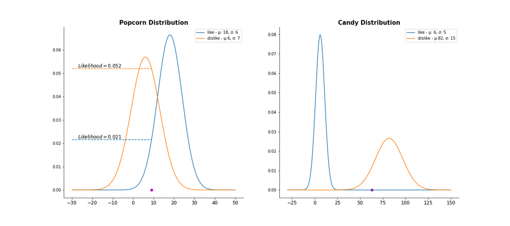

```python
Image('GaussianSolutionPopcandy.png')
```

## Likes Inception

**Prior**:

P(A) = $\frac{1}{2}$

**Likelihood of evidence**:

L(Popcorn = 9|Likes) = 0.021586

L(Candy = 63|Likes) = 4.802e-30

#### To avoid underflow (accuracy of caluclation with really small numbers) we log our likelihoods

$$Log(P(A).L(Popcorn = 9|Likes).L(Candy = 63|Likes))$$$$log(0.5)+log(0.021586)+log(4.802e-30) = -72$$

## Disikes Inception

**Prior**:

P(A) = $\frac{1}{2}$

**Likelihood of evidence**:

L(Popcorn = 9|Dislikes) = 0.0519

L(Candy = 63|Dislikes) = 0.0119

# Appendix

**Libraries**:

```
import numpy as np
import matplotlib.pyplot as plt
from scipy.stats import norm
from IPython.display import display
from IPython.display import Image
```

**Plots**:

```
popcorn = np.arange(-30, 50, 0.001)
candy = np.arange(-30, 150, 0.001)

fig,(ax1,ax2)= plt.subplots(1,2,figsize=(18,8))

ax1.plot(popcorn, norm.pdf(popcorn, 18, 6), label='like - μ: 18, σ: 6')
ax1.plot(popcorn, norm.pdf(popcorn, 6, 7), label='dislike - μ:6, σ: 7')
ax1.scatter(9,0,c = 'm')
ax1.plot([-30,9],[0.02158626594431529,0.02158626594431529], 'tab:blue',linestyle = '--')
ax1.plot([-30,9],[0.05199096024506909,0.05199096024506909], 'tab:orange',linestyle = '--')
ax1.text(-27, 0.0525, '$Likelihood = 0.052$', fontsize = 12,c = 'black')
ax1.text(-27, 0.022, '$Likelihood = 0.021$', fontsize = 12,c = 'black')

# Remove top and right spines
ax1.spines['top'].set_visible(False)
ax1.spines['right'].set_visible(False)
ax1.set_title('Popcorn Distribution',fontweight="bold", size = 15)

# Providing subplots with titles
ax1.xaxis.set_tick_params(labelsize = 12)
ax1.legend(loc='upper right')

#Plot second graph
#plt.setp(ax1, xticks=[0,200,400,600,800,1000], xticklabels=[0,0.2,0.4,0.6,0.8,1])
ax2.plot(candy, norm.pdf(candy, 6, 5), label='like - μ: 6, σ: 5')
ax2.plot(candy, norm.pdf(candy, 82, 15), label='dislike - μ:82, σ: 15')
ax2.scatter(63,0,c = 'm')

# Remove top and right spines
ax2.spines['top'].set_visible(False)
ax2.spines['right'].set_visible(False)

# Providing subplots with titles
ax2.xaxis.set_tick_params(labelsize = 12)
ax2.legend(loc="upper right")
ax2.set_title('Candy Distribution',fontweight="bold", size = 15)

fig.savefig('GaussianSolutionPopcandy.png')
```